# Interview Challenge - Google Map

## 1. Business Problem Statement

## 2. Data Challenge Table

### Table 1: Historical Traffic Dataset (HTD)

| Column Header | Description |
| --- | --- |
| Column Name | Description |
| traffic_id | Unique identifier for each traffic data point. |
| location_id | Identifier for each specific location (interconnected with RAED). |
| timestamp | The time at which the traffic data was recorded (YYYY-MM-DD HH:MM:SS). |
| speed | Average speed of vehicles (km/h) at the given time. |
| volume | Number of vehicles passing through the location at the given time. |
| congestion | Congestion level(continuous variable). |

### Table 2: Road Attribute and Event Dataset (RAED)

| Column Header | Description |
| --- | --- |
| location_id | Identifier for each specific location (interconnected with HTD). |
| road_type | Type of road - 'Highway', 'Main Road', 'Side Street', etc. |
| num_lanes | Number of lanes on the road. |
| event_id | Unique identifier for a specific event (like a concert, football match, etc.). Null if no event. |
| event_type | Type of event if exists - 'Sporting', 'Concert', 'Festival', etc. Null if no event. |
| event_timestamp | Start time of the event (YYYY-MM-DD HH:MM:SS). Null if no event. |
| weather | Weather condition at the time - 'Sunny', 'Rainy', 'Snowy', etc. |

### Load data

```python
import pandas as pd
htd = pd.read_csv('https://storage.googleapis.com/datalynn-datasets/interview-challenge/technology/Google_Map_traffic%20conditions/htd.csv')
raed = pd.read_csv('https://storage.googleapis.com/datalynn-datasets/interview-challenge/technology/Google_Map_traffic%20conditions/raed.csv')
```

## 3. Questions for the Data Challenge

### 3.1 Data Manipulation

- Given the Historical Traffic Dataset (HTD) and Road Attribute and Event Dataset (RAED), how would you merge these datasets to maximize the data's usefulness for traffic prediction? Consider issues like differing time granularities, missing values, and outlier handling.
- Since traffic data is temporal and location-based, how would you structure the data to capture this complex interplay? Describe a strategy to manage time series data with the spatial dimension.

**Ans**: 3.1.1

```python
# Load datasets
# htd = pd.read_csv('htd.csv', parse_dates=['timestamp'])
# raed = pd.read_csv('raed.csv', parse_dates=['event_timestamp'])

# Convert timestamps to the same granularity (hourly in this example)
htd['timestamp'] = pd.to_datetime(htd['timestamp'])
htd['timestamp'] = htd['timestamp'].dt.floor('H')

raed['event_timestamp'] = pd.to_datetime(raed['event_timestamp'])
raed['event_timestamp'] = raed['event_timestamp'].dt.floor('H')

# Merge datasets on both location_id and timestamp
merged_df = pd.merge(htd, raed, left_on=['location_id', 'timestamp'], right_on=['location_id', 'event_timestamp'], how='left')

# Fill missing values for event_type with 'No Event'
merged_df['event_type'] = merged_df['event_type'].fillna('No Event')

# Handling outliers
# This is just an example and you might need to adjust this based on your specific use case
Q1 = merged_df['volume'].quantile(0.25)
Q3 = merged_df['volume'].quantile(0.75)
IQR = Q3 - Q1

filter = (merged_df['volume'] >= Q1 - 1.5 * IQR) & (merged_df['volume'] <= Q3 + 1.5 *IQR)
merged_df = merged_df[filter]

# Mapping weather conditions to numerical values
weather_conditions_mapping = {'Sunny': 0, 'Rainy': 1, 'Snowy': 2}
merged_df['weather'] = merged_df['weather'].map(weather_conditions_mapping)

# Extract day of week, month and hour from timestamp
merged_df['day_of_week'] = merged_df['timestamp'].dt.dayofweek
merged_df['month'] = merged_df['timestamp'].dt.month
merged_df['hour'] = merged_df['timestamp'].dt.hour

# Create a binary feature indicating if there is an event or not
merged_df['has_event'] = merged_df['event_type'].apply(lambda x: 0 if x == 'No Event' else 1)
```

```python
print(merged_df.head())
```

```
   traffic_id  location_id  timestamp       speed  volume  congestion  \
0           1           34 2023-07-22   46.740415      45    1.185818
1           2           96 2023-10-17  108.810296     207   -1.197688
2           3           61 2023-10-24   65.170819      35   -0.154728
3           4           39 2021-02-18   50.059774     270    0.999979
4           5            1 2023-07-04   27.599400     329    1.558639

  road_type  num_lanes  event_id event_type event_timestamp  weather  \
0       NaN        NaN       NaN   No Event             NaT      NaN
1       NaN        NaN       NaN   No Event             NaT      NaN
2       NaN        NaN       NaN   No Event             NaT      NaN
3       NaN        NaN       NaN   No Event             NaT      NaN
4       NaN        NaN       NaN   No Event             NaT      NaN

   day_of_week  month  hour  has_event
0            5      7     0          0
1            1     10     0          0
2            1     10     0          0
3            3      2     0          0
4            1      7     0          0
```

**Ans**: 3.1.2

### 3.2 Metric Selection

- Given the unique problem statement, how would you create a custom evaluation metric that directly relates to our goal of minimizing travel time for users?
- How would you consider the business impact while selecting your metrics? For instance, how might the cost of under-prediction compare to the cost of over-prediction in terms of user satisfaction?

**Ans**: 3.2.1

**Ans**: 3.2.2

### 3.3 Feature Engineering

- Weather and traffic congestion are often correlated. How would you quantify this relationship and incorporate it into your features?
- Consider the temporal patterns in the data. How would you engineer features to capture patterns at different granularities (hourly, daily, monthly, annually)?

**Ans**: 3.3.1

```python
# Merge weather data from RAED to HTD
htd = pd.merge(htd, raed[['location_id', 'weather']], on='location_id', how='left')

# Perform one-hot encoding
weather_encoded = pd.get_dummies(htd['weather'])

# Concatenate the dataframe with the original dataframe
htd = pd.concat([htd, weather_encoded], axis=1)
```

```python
correlation = htd[['congestion', 'Sunny', 'Rainy', 'Snowy']].corr()
print(correlation)
```

```
            congestion     Sunny     Rainy     Snowy
congestion    1.000000 -0.012361  0.015334 -0.002030
Sunny        -0.012361  1.000000 -0.492642 -0.552248
Rainy         0.015334 -0.492642  1.000000 -0.453434
Snowy        -0.002030 -0.552248 -0.453434  1.000000
```

**Ans**: 3.3.2

```python
# Convert timestamp to datetime
htd['timestamp'] = pd.to_datetime(htd['timestamp'])

# Create temporal features
htd['hour'] = htd['timestamp'].dt.hour
htd['day'] = htd['timestamp'].dt.day
htd['month'] = htd['timestamp'].dt.month
htd['year'] = htd['timestamp'].dt.year
```

### 3.4 Model Selection

Establish a regression model to predict traffic conditions.

**Ans**: 3.4

```python
from sklearn.model_selection import train_test_split
from sklearn.linear_model import LinearRegression
from sklearn.metrics import mean_squared_error, r2_score

# Selecting the independent variables (features) and the dependent variable (target)
features = htd[['traffic_id', 'speed', 'Sunny', 'Rainy', 'Snowy', 'hour', 'day', 'month', 'year']]
target = htd['congestion']

# Split the data into training set and test set
X_train, X_test, y_train, y_test = train_test_split(features, target, test_size=0.2, random_state=42)

# Create a Linear Regression object
lr = LinearRegression()

# Train the model
lr.fit(X_train, y_train)

# Make predictions using the testing set
y_pred = lr.predict(X_test)

# Print the coefficients of the model
print('Coefficients: \n', lr.coef_)

# Print the mean squared error
print('Mean squared error: %.2f' % mean_squared_error(y_test, y_pred))

# Print the coefficient of determination: 1 is perfect prediction
print('Coefficient of determination: %.2f' % r2_score(y_test, y_pred))
```

```
Coefficients:
 [ 0.00989811 -0.01979302 -0.05071352  0.05926448 -0.00855096  0.
 -0.00187253  0.00435269  0.01867678]
Mean squared error: 0.29
Coefficient of determination: 0.97
```

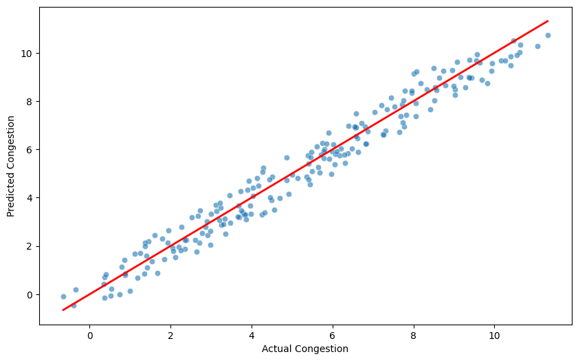

```python
import matplotlib.pyplot as plt
import seaborn as sns

# Visualizing the results
plt.figure(figsize=(10, 6))

# Scatter plot of actual and predicted values
sns.scatterplot(x=y_test, y=y_pred, alpha=0.6)
plt.xlabel('Actual Congestion')
plt.ylabel('Predicted Congestion')

# Plot a line for perfect correlation
min_val = min(min(y_test), min(y_pred))
max_val = max(max(y_test), max(y_pred))
plt.plot([min_val, max_val], [min_val, max_val], color='red', linewidth=2)

plt.show()
```

### 3.5 Model Optimization and Evaluation

- Discuss how you would improve your model. What techniques would you use and why?
- How would you approach the evaluation of model fairness and bias, considering that traffic conditions might affect different users unequally?

**Ans**: 3.5.1

```python
from sklearn.ensemble import RandomForestRegressor

# Create a Random Forest Regressor object
rfr = RandomForestRegressor(n_estimators=200, random_state=42)

# Train the model
rfr.fit(X_train, y_train)

# Make predictions using the testing set
y_pred_rf = rfr.predict(X_test)

# Print the mean squared error
print('Mean squared error: %.2f' % mean_squared_error(y_test, y_pred_rf))

# Print the coefficient of determination: 1 is perfect prediction
print('Coefficient of determination: %.2f' % r2_score(y_test, y_pred_rf))
```

```
Mean squared error: 0.36
Coefficient of determination: 0.96
```

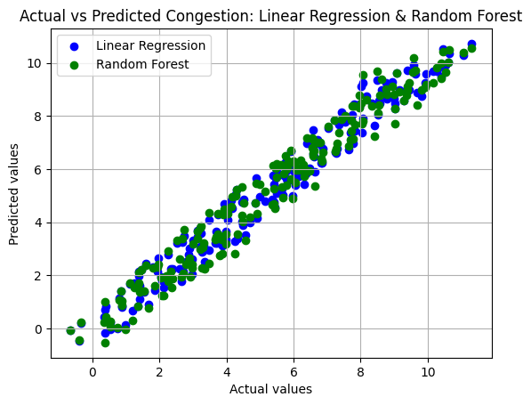

```python
# Create a scatter plot of the actual vs. predicted values
plt.scatter(y_test, y_pred, color='blue', label='Linear Regression')
plt.scatter(y_test, y_pred_rf, color='green', label='Random Forest')
plt.xlabel('Actual values')
plt.ylabel('Predicted values')
plt.title('Actual vs Predicted Congestion: Linear Regression & Random Forest')
plt.legend()
plt.grid(True)
plt.show()
```

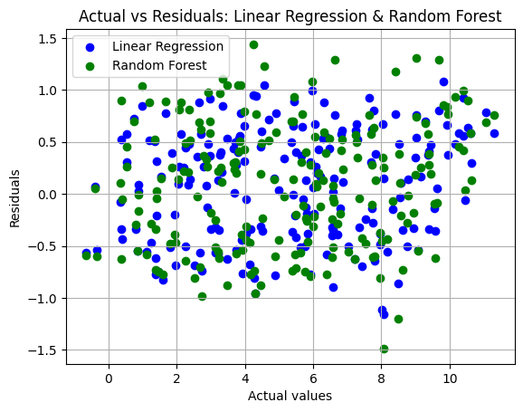

```python
# Calculate residuals
residuals_lr = y_test - y_pred
residuals_rf = y_test - y_pred_rf

# Create a scatter plot of the actual vs. residuals
plt.scatter(y_test, residuals_lr, color='blue', label='Linear Regression')
plt.scatter(y_test, residuals_rf, color='green', label='Random Forest')
plt.xlabel('Actual values')
plt.ylabel('Residuals')
plt.title('Actual vs Residuals: Linear Regression & Random Forest')
plt.legend()
plt.grid(True)
plt.show()
```

**Ans**: 3.5.2

### 3.6 Business Insights

- Based on your model, what kind of interventions could Google Maps suggest to city planners to improve traffic conditions?
- How would you design a system to continuously evaluate the model's performance after deployment, and how would it inform you of any significant performance degradation?

**Ans**: 3.6.1

**Ans**: 3.6.2